# 498818_SDS496_HW6

Problem 1. Download the wine data set under Modules on Canvas. The data set contains measurements for 178 wines produced in a specific area of Italy.

We are interested in predicting the type of wine (Type – qualitative variable with 3 levels) given only information on its alcohol level (Alcohol) and total phenolic contents (Phenols).

```python
import pandas as pd
import numpy as np
import matplotlib.pyplot as plt


file_path = "/Users/aidanashrafi/Downloads/wine.csv"
data_df = pd.read_csv(file_path)
print(data_df.isna().sum(), "\n")

print(data_df.head(), "\n")
print(data_df.describe(), "\n")
print(data_df.shape[0])
```

```
Type               0
Alcohol            0
Malic              0
Ash                0
Alcalinity         0
Magnesium          0
Phenols            0
Flavanoids         0
Nonflavanoids      0
Proanthocyanins    0
Color              0
Hue                0
Dilution           0
Proline            0
dtype: int64

   Type  Alcohol  Malic   Ash  Alcalinity  Magnesium  Phenols  Flavanoids  \
0     1    14.23   1.71  2.43        15.6        127     2.80        3.06
1     1    13.20   1.78  2.14        11.2        100     2.65        2.76
2     1    13.16   2.36  2.67        18.6        101     2.80        3.24
3     1    14.37   1.95  2.50        16.8        113     3.85        3.49
4     1    13.24   2.59  2.87        21.0        118     2.80        2.69

   Nonflavanoids  Proanthocyanins  Color   Hue  Dilution  Proline
0           0.28             2.29   5.64  1.04      3.92     1065
1           0.26             1.28   4.38  1.05      3.40     1050
2           0.30             2.81   5.68  1.03      3.17     1185
3           0.24             2.18   7.80  0.86      3.45     1480
4           0.39             1.82   4.32  1.04      2.93      735

             Type     Alcohol       Malic         Ash  Alcalinity   Magnesium  \
count  178.000000  178.000000  178.000000  178.000000  178.000000  178.000000
mean     1.938202   13.000618    2.336348    2.366517   19.494944   99.741573
std      0.775035    0.811827    1.117146    0.274344    3.339564   14.282484
min      1.000000   11.030000    0.740000    1.360000   10.600000   70.000000
25%      1.000000   12.362500    1.602500    2.210000   17.200000   88.000000
50%      2.000000   13.050000    1.865000    2.360000   19.500000   98.000000
75%      3.000000   13.677500    3.082500    2.557500   21.500000  107.000000
max      3.000000   14.830000    5.800000    3.230000   30.000000  162.000000

          Phenols  Flavanoids  Nonflavanoids  Proanthocyanins       Color  \
count  178.000000  178.000000     178.000000       178.000000  178.000000
mean     2.295112    2.029270       0.361854         1.590899    5.058090
std      0.625851    0.998859       0.124453         0.572359    2.318286
min      0.980000    0.340000       0.130000         0.410000    1.280000
25%      1.742500    1.205000       0.270000         1.250000    3.220000
50%      2.355000    2.135000       0.340000         1.555000    4.690000
75%      2.800000    2.875000       0.437500         1.950000    6.200000
max      3.880000    5.080000       0.660000         3.580000   13.000000

              Hue    Dilution      Proline
count  178.000000  178.000000   178.000000
mean     0.957449    2.611685   746.893258
std      0.228572    0.709990   314.907474
min      0.480000    1.270000   278.000000
25%      0.782500    1.937500   500.500000
50%      0.965000    2.780000   673.500000
75%      1.120000    3.170000   985.000000
max      1.710000    4.000000  1680.000000

178
```

i. How many observations are there available for each type of wine?

```python
print(data_df['Type'].value_counts(), "\n")
```

```
2    71
1    59
3    48
Name: Type, dtype: int64
```

There are 71 observations of type 2, 59 observations of type 1, and 48 observations of type 3.

ii. Split the data set into a training set and a test set. Fit a suitable multinomial logistic regression model on the training set. Provide a matrix of the estimated coefficients.

```python
from sklearn.model_selection import train_test_split
import statsmodels.api as sm

# Independent variables (predictors: Alcohol and Phenols)
X = data_df[['Alcohol', 'Phenols']]

# Dependent variable (response: Type of wine)
y = data_df['Type']

# Split the data into training and test sets
X_train, X_test, y_train, y_test = train_test_split(X, y, test_size=0.2, random_state=0)

# Add a constant (intercept) to the training set
X_train_mnl = sm.add_constant(X_train)
X_test_mnl = sm.add_constant(X_test)

# Fit the multinomial logistic regression model
model = sm.MNLogit(y_train, X_train_mnl)
fit = model.fit(method="lbfgs", maxiter=1000, disp=0)

# Display the model summary
print(fit.summary(), "\n")

print(fit.params)
```

```
                          MNLogit Regression Results
==============================================================================
Dep. Variable:                   Type   No. Observations:                  142
Model:                        MNLogit   Df Residuals:                      136
Method:                           MLE   Df Model:                            4
Date:                Thu, 24 Oct 2024   Pseudo R-squ.:                  0.6187
Time:                        12:28:36   Log-Likelihood:                -59.115
converged:                       True   LL-Null:                       -155.04
Covariance Type:            nonrobust   LLR p-value:                 2.117e-40
==============================================================================
    Type=2       coef    std err          z      P>|z|      [0.025      0.975]
------------------------------------------------------------------------------
const         56.4640     10.413      5.422      0.000      36.054      76.874
Alcohol       -3.8909      0.779     -4.994      0.000      -5.418      -2.364
Phenols       -2.2769      0.974     -2.339      0.019      -4.185      -0.369
------------------------------------------------------------------------------
    Type=3       coef    std err          z      P>|z|      [0.025      0.975]
------------------------------------------------------------------------------
const         17.5417     10.372      1.691      0.091      -2.787      37.871
Alcohol       -0.3195      0.778     -0.411      0.681      -1.845       1.206
Phenols       -5.8839      1.086     -5.420      0.000      -8.012      -3.756
==============================================================================

                 0          1
const    56.464009  17.541666
Alcohol  -3.890928  -0.319545
Phenols  -2.276926  -5.883909
```

The output shows the Multinomial Logistic Regression summary statistics, and the matrix of estimated coefficients.

iii. How many decision boundaries exist for this qualitative response variable? Provide the estimated decision boundaries based on this model.

## There are 3 Decision Boundaries (Type 1 vs Type 2, Type 1 vs Type 3, and Type 2 vs Type 3)

## 1. Type 1 vs Type 2

$$ 56.464009 - 3.890928 \cdot Alcohol - 2.276926 \cdot Phenols = 0 $$

## 2. Type 1 vs Type 3

$$ 17.541666 - 0.319545 \cdot Alcohol - 5.883909 \cdot Phenols = 0 $$

## 3. Type 2 vs Type 3

$$ 38.922343 - 3.571383 \cdot Alcohol + 3.606983 \cdot Phenols = 0 $$

iv. Create a scatterplot of Phenols (y-axis) vs. Alcohol (x-axis) and color the observations based on the type of wine. Overlay the estimated decision boundaries on the scatterplot.

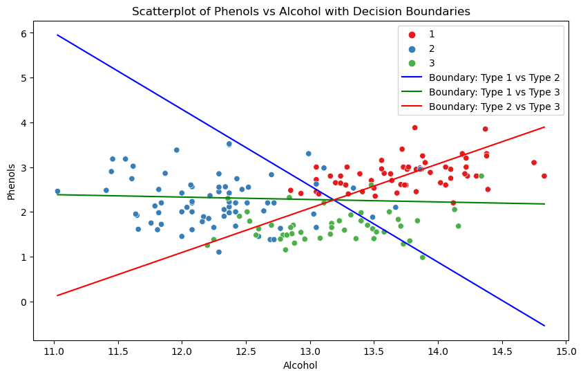

```python
import seaborn as sns


plt.figure(figsize=(10, 6))
sns.scatterplot(data=data_df, x='Alcohol', y='Phenols', hue='Type', palette='Set1')

# Generate a grid of Alcohol values for plotting decision boundaries
alcohol_values = np.linspace(data_df['Alcohol'].min(), data_df['Alcohol'].max(), 100)

# 1. Type 1 vs Type 2 boundary: 56.464009 - 3.890928 * Alcohol - 2.276926 * Phenols = 0
phenols_12 = (56.464009 - 3.890928 * alcohol_values) / 2.276926
plt.plot(alcohol_values, phenols_12, color='blue', label='Boundary: Type 1 vs Type 2')

# 2. Type 1 vs Type 3 boundary: 17.541666 - 0.319545 * Alcohol - 5.883909 * Phenols = 0
phenols_13 = (17.541666 - 0.319545 * alcohol_values) / 5.883909
plt.plot(alcohol_values, phenols_13, color='green', label='Boundary: Type 1 vs Type 3')

# 3. Type 2 vs Type 3 boundary: 38.922343 - 3.571383 * Alcohol + 3.606983 * Phenols = 0
phenols_23 = (38.922343 - 3.571383 * alcohol_values) / -3.606983
plt.plot(alcohol_values, phenols_23, color='red', label='Boundary: Type 2 vs Type 3')

# Set plot labels and title
plt.xlabel('Alcohol')
plt.ylabel('Phenols')
plt.title('Scatterplot of Phenols vs Alcohol with Decision Boundaries')
plt.legend()

# Show plot
plt.show()
```

v. Calculate the confusion matrix and the misclassification rate on the test set.

```python
import numpy as np
import pandas as pd
from sklearn.metrics import accuracy_score


X_test_mnl = sm.add_constant(X_test)
# Predicted probabilities for each class (similar to predict_proba)
predicted_probs = fit.predict(X_test_mnl)

# Convert predicted probabilities to class predictions by taking the class with the highest probability
predicted_class = predicted_probs.idxmax(axis=1)

# Adjust predicted_class to match the labels in y_test (add 1 to zero-indexed predictions)
predicted_class = predicted_class + 1

# Generate confusion matrix using crosstab
conf_matrix = pd.crosstab(y_test, predicted_class, rownames=['Actual'], colnames=['Predicted'])

# Calculate accuracy
accuracy = accuracy_score(y_test, predicted_class)

# Calculate misclassification rate
misclassification_rate = 1 - accuracy

# Print results
print("Confusion Matrix:\n", conf_matrix)
print("Misclassification Rate:", misclassification_rate)
```

```
Confusion Matrix:
 Predicted   1   2  3
Actual
1          13   1  0
2           2  14  0
3           0   1  5
Misclassification Rate: 0.11111111111111116
```

Problem 2. We are now interested in predicting the type of wine (Type – qualitative variable with 3 levels) given only information on its alcohol level (Alcohol – quantitative variable).

i. Calculate the group variances of Alcohol stratified by wine type. Are they roughly equal to each other?

```python
# Calculate the variance of Alcohol for each wine type
alcohol_variances = data_df.groupby('Type')['Alcohol'].var()

# Display the variances for each wine type
print("Group Variances of Alcohol by Wine Type:\n", alcohol_variances)
```

```
Group Variances of Alcohol by Wine Type:
 Type
1    0.213560
2    0.289406
3    0.281156
Name: Alcohol, dtype: float64
```

Yes, the group variances are roughly equal to each other.

ii. Create histograms of alcohol level stratified by wine type. Do the distributions of observed alcohol values within each wine type appear to be roughly symmetric (normally distributed)?

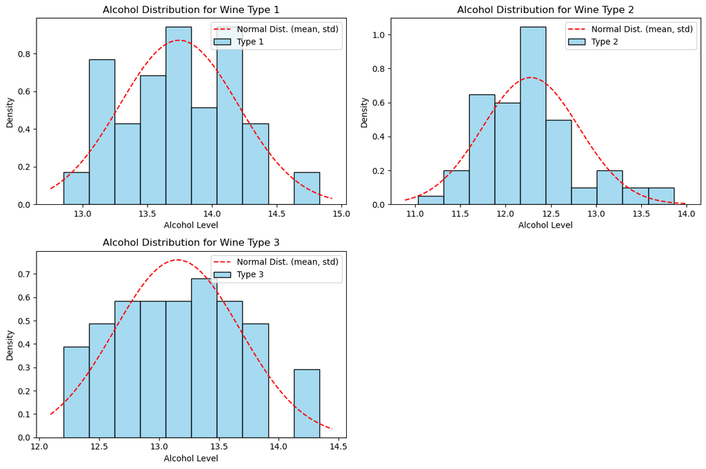

```python
from scipy.stats import norm

# Set up the figure for subplots
plt.figure(figsize=(12, 8))

# Get the unique wine types
wine_types = data_df['Type'].unique()

# Loop through each wine type and plot
for i, wine_type in enumerate(wine_types, 1):
    plt.subplot(2, 2, i)  # Create subplots (adjust rows/columns based on number of wine types)

    # Subset the data for the current wine type
    subset = data_df[data_df['Type'] == wine_type]['Alcohol']

    # Plot the histogram for Alcohol for the current wine type
    sns.histplot(subset, kde=False, bins=10, stat="density", color="skyblue", label=f"Type {wine_type}")

    # Overlay the normal distribution curve
    mu, std = norm.fit(subset)  # Fit a normal distribution and get the mean (mu) and standard deviation (std)
    xmin, xmax = plt.xlim()  # Get the limits of the x-axis for the plot
    x = np.linspace(xmin, xmax, 100)
    p = norm.pdf(x, mu, std)  # Calculate the normal distribution
    plt.plot(x, p, 'r--', label='Normal Dist. (mean, std)')

    # Set titles and labels
    plt.title(f"Alcohol Distribution for Wine Type {wine_type}")
    plt.xlabel('Alcohol Level')
    plt.ylabel('Density')
    plt.legend()

# Adjust layout and show the plot
plt.tight_layout()
plt.show()
```

Yes, the distributions for the observed alcohol values within each wine type appear to be roughly symmetric (normally distributed).

iii. Fit a suitable linear discriminant analysis model on the training set. Provide the estimates of the prior class probabilities and the group means. What’s the default choice of prior class probabilities? Provide histograms of the linear discriminant function stratified by wine type. Are there visible differences in the distributions of the linear discriminant function among different wine types?

```
Prior Class Probabilities (for Wine Types 1, 2, 3): [0.31690141 0.38732394 0.29577465]

Group Means (for Wine Types 1, 2, 3):
                Alcohol   Phenols
Wine Type 1  13.724667  2.833111
Wine Type 2  12.265636  2.213091
Wine Type 3  13.134048  1.702857
```

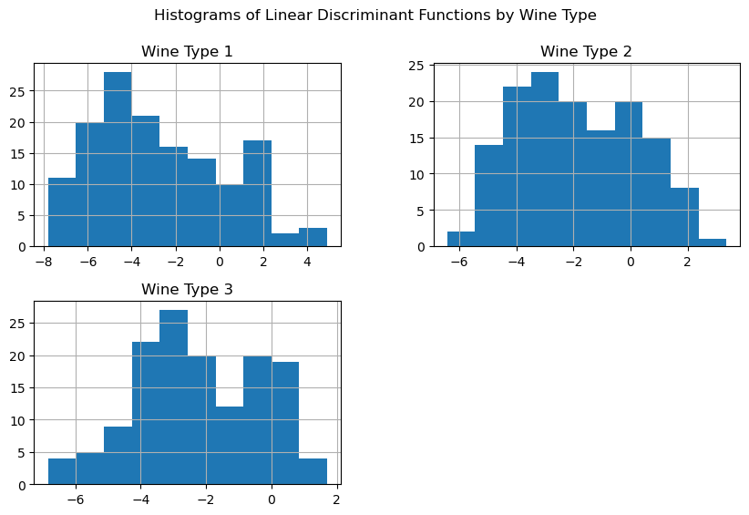

```python
from sklearn.discriminant_analysis import LinearDiscriminantAnalysis

# Fit LDA model
lda_model = LinearDiscriminantAnalysis()
fit_lda = lda_model.fit(X_train, y_train)

# 1. Print prior class probabilities (default based on training set)
print("Prior Class Probabilities (for Wine Types 1, 2, 3):", fit_lda.priors_)

# 2. Cleaner output for group means
# Define feature names for easier interpretation
features = ['Alcohol', 'Phenols']

# Create a DataFrame for cleaner output
group_means_df = pd.DataFrame(fit_lda.means_, columns=features, index=['Wine Type 1', 'Wine Type 2', 'Wine Type 3'])

# Print the DataFrame for group means
print("\nGroup Means (for Wine Types 1, 2, 3):\n", group_means_df)

# 3. Decision function (Linear Discriminants)
decision = fit_lda.decision_function(X_train)
decision_df = pd.DataFrame(decision)

# Rename the columns to reflect wine types 1, 2, 3
decision_df.columns = [f'Wine Type {i+1}' for i in range(decision_df.shape[1])]

# Plot histograms of the decision function values (discriminant scores)
decision_df.hist(figsize=(10, 6))
plt.suptitle('Histograms of Linear Discriminant Functions by Wine Type')
plt.show()
```

**Prior Class Probabilities (for Wine Types 1, 2, 3): [0.31690141 0.38732394 0.29577465].**

**Group Means (for Wine Types 1, 2, 3):**

```
           Alcohol      Phenols
```

Wine Type 1 **13.724667 2.833111**

Wine Type 2 **12.265636 2.213091**

Wine Type 3 **13.134048 1.702857**

iv. How many decision boundaries exist for this model? Provide the estimated decision boundaries given equal prior class probabilities

There are 3 decision boundaries for this model.

```python
import numpy as np
from numpy.linalg import inv
import numpy as np
from numpy.linalg import inv

# Group means (for each feature: Alcohol and Phenols)
means = lda_model.means_  # No need to skip the intercept because LDA does not include it

# Priors (you already have these from the model output)
priors = lda_model.priors_

# Calculate the shared covariance matrix
n_features = X_train.shape[1]  # Number of features (Alcohol, Phenols)

# Initialize the covariance matrix
cov_matrix = np.zeros((n_features, n_features))

# Calculate the within-class covariance matrix (shared for LDA)
for i in range(len(means)):
    X_class = X_train[y_train == i+1]  # Get data for class i (adjust for 1-based indexing)
    cov_matrix += np.cov(X_class.T) * (X_class.shape[0] - 1)

# Normalize by the total number of samples minus the number of classes
cov_matrix /= (len(X_train) - len(means))

# Use the diagonal values as variance (since we assume equal variance for LDA)
variance = np.mean(np.diag(cov_matrix))

# Function to calculate decision boundary between two classes
def calculate_decision_boundary(mu_k, mu_l, prior_k, prior_l, variance):
    log_prior_ratio = np.log(prior_k / prior_l)
    mean_diff = mu_k - mu_l
    boundary = (mu_k + mu_l) / 2 - (variance / mean_diff) * log_prior_ratio
    return boundary

# Calculate decision boundaries between each pair of classes
boundaries = []
for i in range(len(means)):
    for j in range(i + 1, len(means)):
        boundary_alcohol = calculate_decision_boundary(means[i, 0], means[j, 0], priors[i], priors[j], variance)
        boundary_phenols = calculate_decision_boundary(means[i, 1], means[j, 1], priors[i], priors[j], variance)
        boundaries.append((i+1, j+1, boundary_alcohol, boundary_phenols))

# Display the estimated decision boundaries
for boundary in boundaries:
    print(f"Decision boundary between Wine Type {boundary[0]} and Wine Type {boundary[1]}:")
    print(f"  Alcohol: {boundary[2]}")
    print(f"  Phenols: {boundary[3]}")
```

```
Decision boundary between Wine Type 1 and Wine Type 2:
  Alcohol: 13.02615695339563
  Phenols: 2.5960629455500506
Decision boundary between Wine Type 1 and Wine Type 3:
  Alcohol: 13.403023253767286
  Phenols: 2.25422324055399
Decision boundary between Wine Type 2 and Wine Type 3:
  Alcohol: 12.769844734941236
  Phenols: 1.8388302638902714
```

v. Calculate the confusion matrix and the misclassification rate on the test set.

```python
response = y_test
types = fit_lda.classes_
prediction = fit_lda.predict_proba(X_test)
prediction = pd.DataFrame(prediction)
prediction = types[prediction.idxmax(axis=1)]
prediction = fit_lda.predict(X_test)
confusion_matrix_lda = pd.crosstab(response, prediction)
rate = np.mean(response != prediction)
rate = 1 - fit_lda.score(X_test, response)
print("Confusion Matrix:", confusion_matrix_lda)
print(rate)
```

```
Confusion Matrix: col_0   1   2  3
Type
1      13   1  0
2       2  14  0
3       0   1  5
0.11111111111111116
```

Problem 3. We are now interested in predicting the type of wine (Type – qualitative variable with 3 levels) given information on multiple quantitative predictors.

i. Calculate the sample correlation coefficients between Alcohol and Phenols stratified by wine type. Are the 2 predictors roughly uncorrelated with each other within each wine type?

```python
import pandas as pd

correlations = data_df.groupby('Type').apply(lambda x: x['Alcohol'].corr(x['Phenols']))

# Print the sample correlation coefficients for each wine type
print("Sample Correlation Coefficients between Alcohol and Phenols for each Wine Type:")
print(correlations)
```

```
Sample Correlation Coefficients between Alcohol and Phenols for each Wine Type:
Type
1    0.420687
2   -0.046321
3    0.210362
dtype: float64
```

ii. Fit a naive Bayes classifier on the training set with only Alcohol and Phenols as predictors. Provide the estimates of the group means and the group variances for each predictor.

```python
from sklearn.naive_bayes import GaussianNB
# Ensure only Alcohol and Phenols are used for the naive Bayes model
X_train_nb = X_train[['Alcohol', 'Phenols']]  # Only Alcohol and Phenols as predictors

# Fit the Naive Bayes model again
naive_model = GaussianNB()
naive_fit = naive_model.fit(X_train_nb, y_train)


print(naive_fit.class_prior_)
```

```
[0.31690141 0.38732394 0.29577465]
```

```python
# Get the group means and group variances
print("Group Means:\n", naive_fit.theta_)
print("Group Variances:\n", naive_fit.var_)
```

```
Group Means:
 [[13.72466667  2.83311111]
 [12.26563636  2.21309091]
 [13.13404762  1.70285714]]
Group Variances:
 [[0.19679378 0.12579477]
 [0.32189005 0.26017408]
 [0.26885267 0.11544422]]
```

iii. How many decision boundaries exist for this model? Provide the estimated decision boundaries given equal prior class probabilities and equal group variances.

There are 3 decision boundaries in this model.

```python
# Group means and variances from the Naive Bayes model
means = naive_fit.theta_  # Means for each class (rows: classes, columns: features)

# Function to calculate decision boundary between two classes (for Alcohol and Phenols)
def calculate_decision_boundary(mu_i, mu_j):
    return (mu_i + mu_j) / 2  # Midpoint between the two means

# Calculate decision boundaries between each pair of classes (for both Alcohol and Phenols)
boundaries_nb = []
for i in range(len(means)):
    for j in range(i + 1, len(means)):
        # Calculate the decision boundary for Alcohol and Phenols
        boundary_nb_alcohol = calculate_decision_boundary(means[i, 0], means[j, 0])
        boundary_nb_phenols = calculate_decision_boundary(means[i, 1], means[j, 1])

        # Append the boundary values for each wine type pair
        boundaries_nb.append((f'Wine Type {i+1} vs Wine Type {j+1}', boundary_nb_alcohol, boundary_nb_phenols))

# Display the estimated decision boundaries
for boundary in boundaries_nb:
    print(f"Decision boundary between {boundary[0]}:")
    print(f"  Alcohol: {boundary[1]}")
    print(f"  Phenols: {boundary[2]}")
```

```
Decision boundary between Wine Type 1 vs Wine Type 2:
  Alcohol: 12.995151515151514
  Phenols: 2.5231010101010103
Decision boundary between Wine Type 1 vs Wine Type 3:
  Alcohol: 13.429357142857139
  Phenols: 2.2679841269841274
Decision boundary between Wine Type 2 vs Wine Type 3:
  Alcohol: 12.699841991341989
  Phenols: 1.9579740259740261
```

iv. Create a scatterplot of Phenols (y-axis) vs. Alcohol (x-axis) and color the observations based on the type of wine. Overlay the estimated decision boundaries given equal prior class probabilities and equal group variances on the scatterplot. How do these decision boundaries compare against those estimated in the first problem?

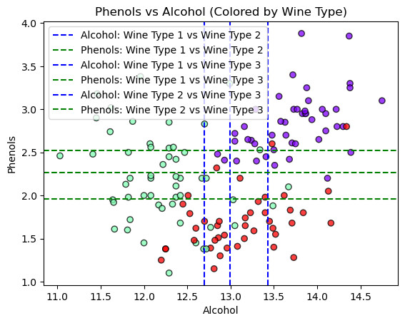

```python
# Scatterplot of Phenols vs Alcohol, colored by wine type
plt.scatter(X_train['Alcohol'], X_train['Phenols'], c=y_train, cmap='rainbow', edgecolors='k', alpha=0.75)
plt.xlabel('Alcohol')
plt.ylabel('Phenols')
plt.title('Phenols vs Alcohol (Colored by Wine Type)')

# Define the decision boundaries for Alcohol and Phenols (based on equal variances and priors)
for boundary in boundaries_nb:
    boundary_label = f"{boundary[0]}"
    plt.axvline(x=boundary[1], linestyle='--', color='blue', label=f'Alcohol: {boundary_label}')
    plt.axhline(y=boundary[2], linestyle='--', color='green', label=f'Phenols: {boundary_label}')

# Add legend for decision boundaries
plt.legend(loc='best')
plt.show()
```

v. Calculate the confusion matrix and the misclassification rate on the test set. How does this classifier compare against the multinomial logistic regression model in the first problem?

```python
# Ensure you're using the correct test set (Alcohol and Phenols only)
X_test_nb = X_test[['Alcohol', 'Phenols']]

# Get the actual responses (wine types)
response_nb = y_test

# Get the predicted classes from Naive Bayes model
prediction_nb = naive_fit.predict(X_test_nb)

# Generate confusion matrix
conf_matrix_nb = pd.crosstab(response_nb, prediction_nb)

# Calculate the misclassification rate
misclassification_rate_nb = 1 - naive_fit.score(X_test_nb, response_nb)

# Print results
print("Confusion Matrix:\n", conf_matrix_nb)
print("Misclassification Rate:", misclassification_rate_nb)
```

```
Confusion Matrix:
 col_0   1   2  3
Type
1      13   1  0
2       2  14  0
3       0   1  5
Misclassification Rate: 0.11111111111111116
```

The results of this classifier is equal to the results of the multinomial logistic regression model in the first problem.

vi. Fit a naive Bayes classifier on the training set with all available quantitative predictors. Calculate the confusion matrix and the misclassification rate on the test set. How does this classifier compare against the classifier in the previous parts?

```python
from sklearn.model_selection import train_test_split
from sklearn.naive_bayes import GaussianNB
import pandas as pd

# Drop the 'Type' column to get the quantitative predictors (features)
X_all = data_df.drop('Type', axis=1)  # All predictors
y_all = data_df['Type']               # Target variable (wine type)

# Split the data into train and test sets
X_train_all, X_test_all, y_train, y_test = train_test_split(X_all, y_all, test_size=0.2, random_state=0)

# Initialize the Naive Bayes model
naive_model_all = GaussianNB()

# Fit the Naive Bayes model with all quantitative predictors
naive_fit_all = naive_model_all.fit(X_train_all, y_train)

# Get the predicted classes from Naive Bayes model for the test set
prediction_nb_all = naive_fit_all.predict(X_test_all)

# Generate confusion matrix for the predictions
conf_matrix_nb_all = pd.crosstab(y_test, prediction_nb_all, rownames=['Actual'], colnames=['Predicted'])

# Calculate the misclassification rate
misclassification_rate_nb_all = 1 - naive_fit_all.score(X_test_all, y_test)

# Print results
print("Confusion Matrix (All Predictors):\n", conf_matrix_nb_all)
print("Misclassification Rate (All Predictors):", misclassification_rate_nb_all)
```

```
Confusion Matrix (All Predictors):
 Predicted   1   2  3
Actual
1          14   0  0
2           2  13  1
3           0   0  6
Misclassification Rate (All Predictors): 0.08333333333333337
```

This classifier is better than all other classifiers, it is more flexible, and has a lower missclassification rate.